# data analyse

```python
import pandas as pd
import seaborn as sns
```

```python
df = pd.read_csv('export.csv')
df.drop(columns='Unnamed: 0', inplace=True)
df.rename(columns={'light_12': 'light'}, inplace=True)
```

## We gaan hier kijken wat het effect is om het drukste stoplicht in de simulatie langer op groen licht te laten.

Het drukste stoplicht was stoplicht 12

**light**: Het stoplicht 0/10/20 % langer op groen laten  
**start_steps**: 252000 = (07:00 – 09:00), 468000 = (13:00 – 15:00) en 576000 = (16:00 – 18:00)  
**avg_car_steps**: Hoeveel steps het gemiddeld kost om over het kruispunt te rijden  
**finished_car_wait**: Hoelang een auto gemiddeld voor een rood stoplicht wacht.

```python
df
```

|  | light | start_steps | avg_car_steps | finished_car_wait |
| --- | --- | --- | --- | --- |
| 0 | 0 | 252000 | 448.286352 | 39.470807 |
| 1 | 10 | 252000 | 497.228335 | 39.941221 |
| 2 | 20 | 252000 | 481.068156 | 40.740250 |
| 3 | 0 | 468000 | 905.426460 | 37.267844 |
| 4 | 10 | 468000 | 728.166016 | 37.480312 |
| 5 | 20 | 468000 | 499.608313 | 36.445932 |
| 6 | 0 | 576000 | 1453.563462 | 38.651728 |
| 7 | 10 | 576000 | 1582.056833 | 37.389947 |
| 8 | 20 | 576000 | 880.616816 | 37.982386 |

Correlatie matrix op het verlengen van het groene licht van het stoplicht

```python
df.corr()[['light']].abs()
```

|  | light |
| --- | --- |
| light | 1.000000 |
| start_steps | 0.000000 |
| avg_car_steps | 0.319575 |
| finished_car_wait | 0.022501 |

start_steps vs average car steps

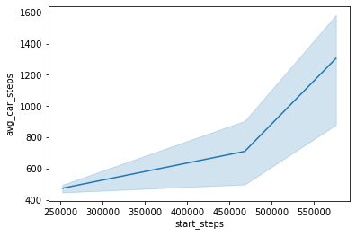

```python
sns.lineplot(data=df, x='start_steps', y='avg_car_steps')
```

start_steps vs finished_car_wait

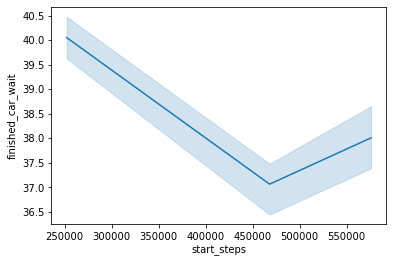

```python
sns.lineplot(data=df, x='start_steps', y='finished_car_wait')
```

Staafdiagram van het effect van het langer op groen laten staan van het stoplicht op het aantal steps een auto gemiddeld doet om over het kruispunt te komen

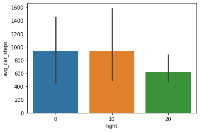

```python
sns.barplot(x="light", y="avg_car_steps", data=df)
```

```python
df0 = df[(df['light'] == 0)]['avg_car_steps'].mean()
df10 = df[(df['light'] == 10)]['avg_car_steps'].mean()
df20 = df[(df['light'] == 20)]['avg_car_steps'].mean()
df0, df10, df20
```

```
(935.7587579951995, 935.8170613404885, 620.4310950019066)
```

Staafdiagram van het effect van het langer op groen laten staan van het stoplicht op de tijd dat een auto gemiddeld voor een rood stoplicht wacht

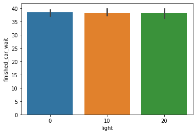

```python
sns.barplot(x="light", y="finished_car_wait", data=df)
```

Staafdiagram van het effect van (ochtendspits/middag/avondspits) op hoelang een auto er gemiddeld over doet om over het kruispunt te komen

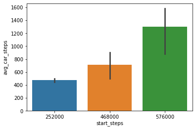

```python
sns.barplot(x="start_steps", y="avg_car_steps", data=df)
```

Staafdiagram van het effect van (ochtendspits/middag/avondspits) op hoelang een auto gemiddeld voor een rood stoplicht staat te wachten

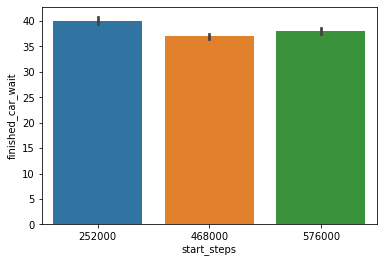

```python
sns.barplot(x="start_steps", y="finished_car_wait", data=df)
```